# SwiftKey Natural Language Processing

Dexter Wang

15 June 2016

# Synopsis

#### SwiftKey is smart input method on mobile devices. It applies Natural Language Processing and machine learning technologies to provide predictions of next words while user is typing.

#### The goal of this project is to develop a similar data product using the knowledge learned from Cursera data science specification.

#### Tasks includes

1. Getting and cleansing blog, news and twitter data.
2. Conduct exploratory data analysis
3. Design an algorithm which could efficiently predict the next word user tends to type, using limited storage and computational resources
4. Develop a data product using Shiny to show its function
5. Demonstrate the project through a presentation.

#### This report shows the early stage progress of the project. It involves an exploration of the source data as well as a proposal of prediction model and data product building process.

# Data Pre-processing

# Data Exploration

#### The table below shows some general statistics on the source data. Note that English stop words takes a large proportion (around 34-42%) of total population. There is an option to retain or remove stop words in the n-gram model, which will be tested later on. In terms of profanity, [a checking list of Google’s banned bad words](https://gist.github.com/ryanlewis/a37739d710ccdb4b406d) is applied for filtering. It turns out that twitter is most informal with 0.46% of bad words which is 10 times higher compared to that of News articles.

```
##         dataset instances word.count stopword profanity
## 1   en_US.blogs    899288   42980468  41.67 %    0.14 %
## 2    en_US.news     77259    3076691  35.36 %    0.04 %
## 3 en_US.twitter   2360148   36741508   34.4 %    0.46 %
```

#### The next step is to investigate the ngrams model. To be more efficient, a small random sample of 1/100 instances from the three sources is chosen to be examined. Since the data is randomly selected, it should reflect the distribution of the true population. The source data are combined and tokenised with profanity and punctuation removed. We build unigram, bigram and trigram on the dataset with or without stop words and compare this two options together.

#### The figures below show the top 20 Unigram, Bigram and Trigram for the cleaned dataset before or after removing stop words. It can be seen that stop words are most frequently used and dominant the top list of the ngrams. After removing stop words, some popular phrases appear on the top list. The dataset seems need to be stemmed so that various forms of words such as negation will also go off the list.

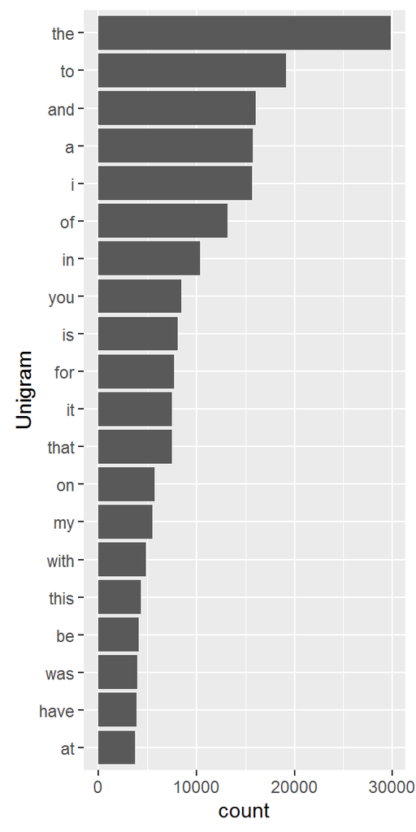

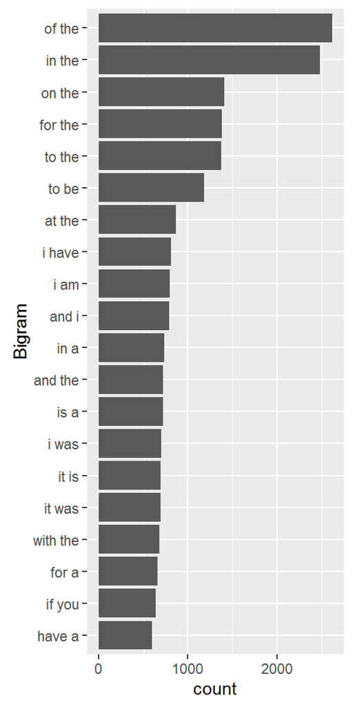

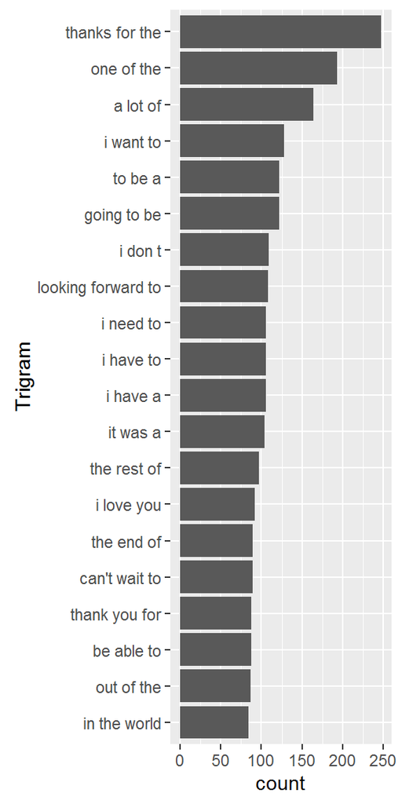

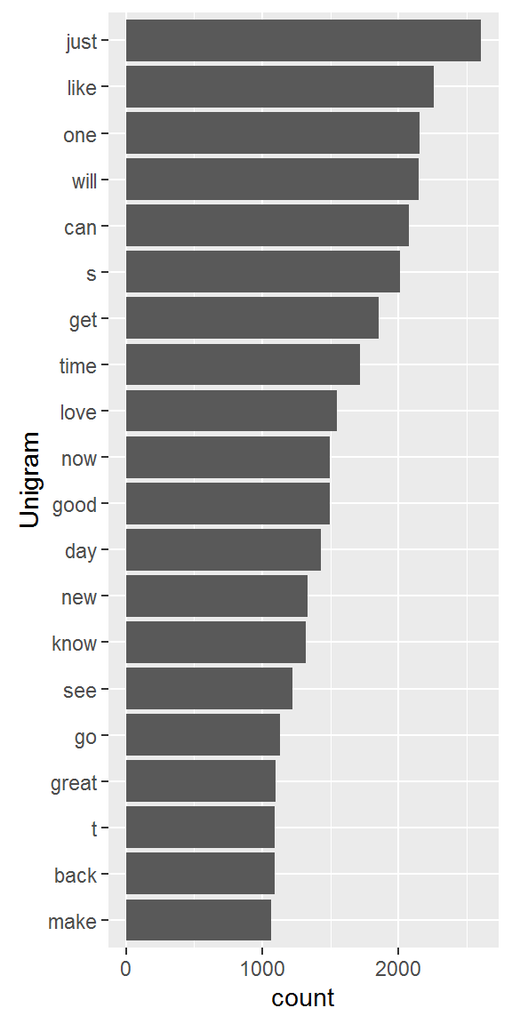

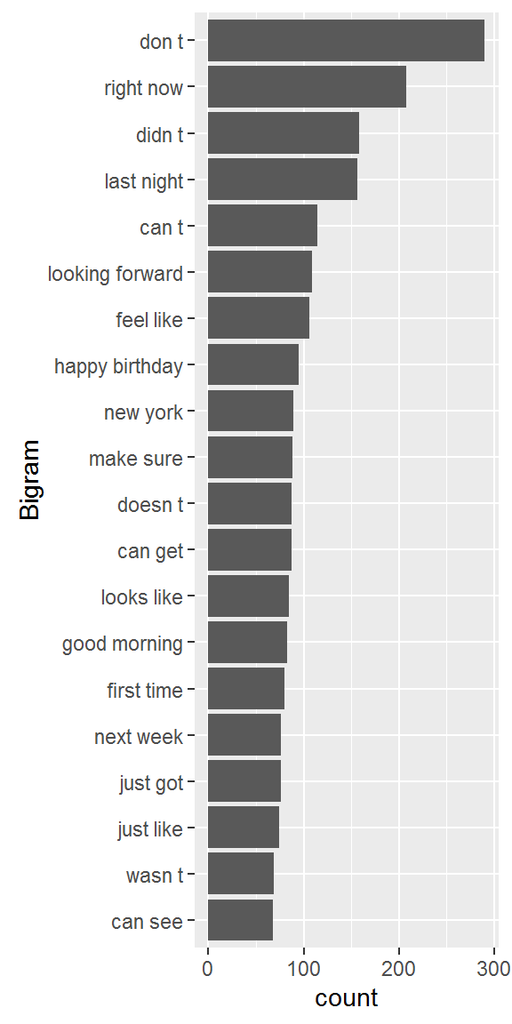

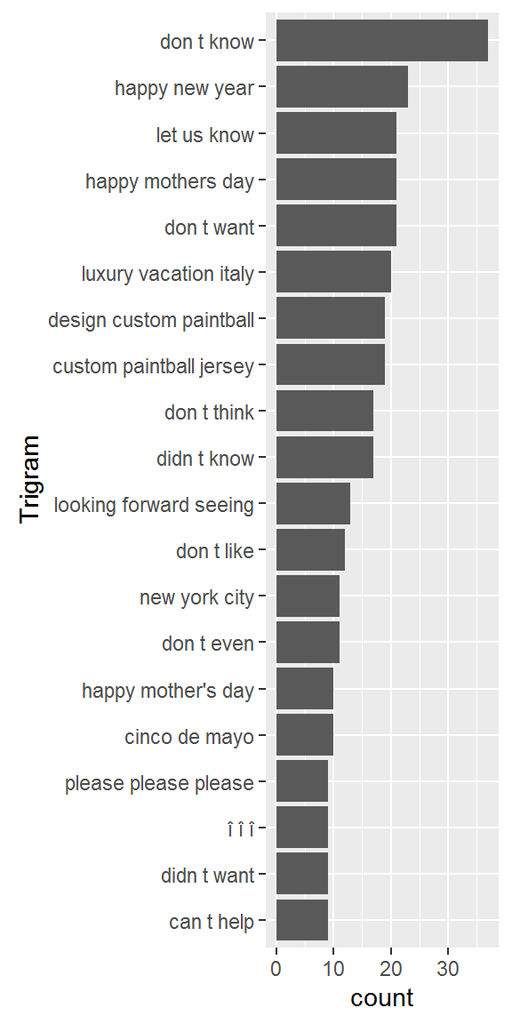

#### The table below shows the number of unique terms required to provide given percentage of coverage of total words in the dataset. It appears that the distribution of the terms are exponential. For example, only 0.27% unique unigrams covers 50% of the total population, but it requires 14.73% to rich a 90% coverage. The Bigrams and Trigrams consists of much more unique combinations and requires exponentialy higher amount of unique terms to provide certain coverage. To rich a 50% coverage of trigrams in the dataset containing stop words, there are 40.88% unique combinations required.

```
##             type Tokens unique.terms coverage.50 percent.50 coverage.90
## 1        Unigram 693324        44036         121     0.27 %        6488
## 2         Bigram 659972       312394       25332     8.11 %      246397
## 3        Trigram 626845       530188      216766    40.88 %      467504
## 4 Unigram_nostop 377597        43863         810     1.85 %       13336
## 5  Bigram_nostop 344339       289574      117405    40.54 %      255141
## 6 Trigram_nostop 312190       308873      152778    49.46 %      277654
##   percent.90
## 1    14.73 %
## 2    78.87 %
## 3    88.18 %
## 4     30.4 %
## 5    88.11 %
## 6    89.89 %
```

# Project planning and discussion

The prediction model will take the user input and try to provide the ranked longest matching as recommendations. For example, once user has input three words, the algorithm will check against the 4-gram, 3-gram and 2-gram respectively trying to match the last 3, 2 and 1 words. A number of matching terms will be returned with the longest matching comes first.

### Current issues

1. Is word stemming necessary before making the n-grams?
- If so, the model will lose the power to predict various terms such as negations or tenses. But there should be some performance gain since the size of the n-gram should be much smaller. One possible way is to do stemming before building n-grams, and put the suffix such as “n’t, ed, ing” back in the recommendations. However, it looks quite complex to achieve.
2. Whether to keep stop words in the n-grams
- Same as above, there is a trade-off between the prediction power and the performance which needs to be tested on. Noting that stop words consists of above 35% of the total words in the learning dataset.
3. How to evaluate the prediction accuracy?
4. How to store the n-grams model to rich better performance?

## Thanks for viewing :)